# Activity IV - Fundamental of Cryptography

By Saenyakorn Siangsanoh 6232035721

## Overviews

In this activity, we will learn the basics of encryption. There are 3 exercises in this activity. Each exercise is designed to let you learn the concepts of cryptography.

We will need:

- Imagemagick
- OpenSSL
- One of your favorite programming languages.

You are welcome to do this exercise with any programming language. If you have no preference, use python.

## Exercises

(Encryption and Statistical Analysis) Though encryption is primarily designed to preserve confidentiality and integrity of data, the mechanism itself is vulnerable to brute force (statistical analysis). In other words, the more we see the encrypted data, the easier we can hack it. In this exercise, you are asked to crack the following cipher text. Please provide the decrypted result and explain your strategy in decrypting this text.

**Cipher text**

```
PRCSOFQX FP QDR AFOPQ CZSPR LA JFPALOQSKR. QDFP FP ZK LIU BROJZK MOLTROE.
```

1. Count the frequency of letters. List the top three most frequent characters

```python
text = "PRCSOFQX FP QDR AFOPQ CZSPR LA JFPALOQSKR. QDFP FP ZK LIU BROJZK MOLTROE."
f = dict()

def find_max_3(f):
    for i in range(3):
        max_key = max(f, key=f.get)
        print(max_key, f[max_key])
        f.pop(max_key)

for c in text:
    if c in f:
        f[c] += 1
    else:
        f[c] = 1

f.pop(' ')
print("Top 3 most frequent characters:")
find_max_3(f)
```

```
Top 3 most frequent characters:
P 7
R 6
O 6
```

1. Knowing that this is English, what are commonly used three-letter words and two-letter words. Does the knowledge give you a hint on cracking the given text?

### Answer

ใช่ เพราะในตอนที่ลอง crack ครั้งแรก การ assume ว่า `FP` เป็น `is` และ `QDR` เป็น `the` ทำให้มองเห็นความสัมพันธ์ระหว่างตัวอักษร และทำให้เดาตัวอักษรถัดไปได้มากขึ้น

1. Cracking the given text. Measure the time that you have taken to crack this message.

### Answer

จากที่ได้ลอง ๆ ดูพบว่าตัวเองใช้เวลาในการเดา ประมาณ 30 นาที ซึ่งสามารถเดาได้ดังนี้

```python
d = dict()
d['F'] = 'i'
d['P'] = 's'
d['Q'] = 't'
d['D'] = 'h'
d['R'] = 'e'
d['Z'] = 'a'
d['K'] = 'n'
d['C'] = 'c'
d['S'] = 'u'
d['O'] = 'r'
d['X'] = 'y'
d['A'] = 'f'
d['L'] = 'o'
d['J'] = 'm'
d['B'] = 'g'
d['I'] = 'l'
d['U'] = 'd'
d['E'] = 'b'
d['M'] = 'p'
d['T'] = 'v'

for c in text:
    if c in d:
        print(d[c], end='')
    else:
        print(c, end='')
```

```
security is the first cause of misfortune. this is an old german proverb.
```

1. Explain your process in hacking such messages.

### Answer

จากที่ได้อธิบายไปในข้อ 2 ผมเริ่มเดาจาก คำที่มี 2 ตัวก่อน จากนั้น 3 ตัว และคำถัดจาก `the` มีความใกล้เคียงกับคำว่า `first` และ context ได้ เลยลองใส่ดูแล้วพบว่าคำแรกสุดใกล้เคียงคำว่า security จากนั้นก็เดาประโยคหลังต่อไป ตามคำที่นึกออกและคิดว่าใกล้เคียง รวมถึงใช้เป็นอักษรที่ยังไม่เคยเดาไปแล้ว

1. If you know that the encryption scheme is based on Caesar(Monoalphabetic Substitution) that is commonly used by Caesar for sending messages to Cicero, does it allow you to crack it faster

### Answer

ง่ายขึ้นอย่างมากเพราะจะได้ไม่ต้องมานั่งเดาตั้งแต่เริ่มว่า text นี้ใช้ encryption ท่าไหน

1. Draw a cipher disc of the given text.

```python
p = list(d.items())
p.sort(key=lambda x: x[1])
top = []
bottom = []
for a, b in p:
  top.append(b)
  bottom.append(a)
print("".join(top))
print("".join(bottom))
```

```
abcdefghilmnoprstuvy
ZECURABDFIJKLMOPQSTX
```

1. Create a simple python program for cracking the Caesar cipher text using brute force attack. Explain the design and demonstrate your software. (You may use an English dictionary for validating results.)

```python
import requests
import re

# Prepare dictionary
dictionary = requests.get("https://raw.githubusercontent.com/dwyl/english-words/master/words.txt").text.split("\n")
# Sample dictionary items
print(dictionary[100:120])
# Analyze dictionary
print("Length 2: ", len(list(filter(lambda x: (len(x) == 2), dictionary))))
print("Length 3: ", len(list(filter(lambda x: (len(x) == 3), dictionary))))
print("Length 4: ", len(list(filter(lambda x: (len(x) == 4), dictionary))))
print("Length 5: ", len(list(filter(lambda x: (len(x) == 5), dictionary))))
print("Length 6: ", len(list(filter(lambda x: (len(x) == 6), dictionary))))
print("Length 7: ", len(list(filter(lambda x: (len(x) == 7), dictionary))))
```

```
['aals', 'Aalst', 'Aalto', 'AAM', 'AAMSI', 'Aandahl', 'A-and-R', 'Aani', 'AAO', 'AAP', 'AAPSS', 'Aaqbiye', 'Aar', 'Aara', 'Aarau', 'AARC', 'aardvark', 'aardvarks', 'aardwolf', 'aardwolves']
Length 2:  637
Length 3:  4711
Length 4:  11171
Length 5:  22950
Length 6:  39518
Length 7:  52093
```

```python
# Prepare cipher text
original_words = "PRCSOFQX FP QDR AFOPQ CZSPR LA JFPALOQSKR. QDFP FP ZK LIU BROJZK MOLTROE.".replace(".", "").split(" ")

# Rearrange words
def reorder_words(words: list):
  score = dict()
  freq = dict()
  length = dict()
  # Unique words
  unique_words = list(set(words))
  # Measure character frequency
  for word in unique_words:
    for c in word:
      if c in freq:
        freq[c] += 1
      else:
        freq[c] = 1
  # Measure word score
  for word in unique_words:
    s = 0
    for c in word: s += freq[c]
    score[word] = s
  # Sort by length and score
  unique_words.sort(key=lambda x: -len(x)*score[x])
  for word in unique_words:
    print(word, len(word), score[word], len(word) / score[word])
  return unique_words

words = reorder_words(original_words)
print(words)
```

[output not shown]

```python
def translate(d: dict, word: str) -> str:
    return "".join([d[c] if c in d else c for c in word])

def transform_to_regex(word: str) -> str:
    regex = "".join(["." if c.isupper() else c for c in word])
    return f'^{regex}$'

def find_word_in_english_dictiory(regex: str, dictionary: list) -> list:
    r = re.compile(regex)
    return list(filter(r.match, dictionary))

def filter_words_with_dict_value(dv: list, words: list) -> list:
    results = []
    for word in words:
        if not any([c in dv for c in word]) and word.isalpha():
            results.append(word)
    return results

def store_translation(d: dict, word: str, translation: str) -> bool:
    for i in range(len(word)):
        if word[i].isupper():
            if translation[i] in d.values():
                return False
            d[word[i]] = translation[i]
    return True

def decrypt(d: dict, words: list, dictionary: list):
    if len(words) == 0:
        print("Found solution: ", d)
        return [d]
    top_word = words[0]
    translate_word = translate(d, top_word)
    if translate_word.islower():
        return decrypt(d, words[1:], dictionary)
    regex = transform_to_regex(translate_word)
    match_words = find_word_in_english_dictiory(regex, dictionary)
    # Filter out words that the chracaters are in the 'd'
    dc = [c for c in translate_word if c.islower()]
    dv = [v for v in list(d.values()) if v not in dc]
    match_words = filter_words_with_dict_value(dv, match_words)
    # Debug print
    join_match_words = ", ".join([x.lower() for x in match_words[:8]])
    print(f"Match {len(match_words)} for {top_word} ({regex}) -> {join_match_words}")
    print("Translate: ", translate(d, " ".join(original_words)))
    results = []
    for w in match_words:
        d2 = d.copy()
        if not store_translation(d2, translate_word, w.lower()):
            continue
        rs = decrypt(d2, words[1:], dictionary)
        if len(rs) > 0:
            results += rs
    return results

# Run decryption
stupid_dictionary = ["aa", "ab", "security", "is", "the", "first", "cause", "of", "misfortune", "this", "is", "an", "old", "german", "proverb"]
results = decrypt(dict(), words, dictionary)
print(results)
```

[output not shown]

[output cut: 5540 more lines]

[output not shown]

```python
for i, d in enumerate(results):
    print(f"Solution {i+1}: ", translate(d, " ".join(original_words)))
```

```
Solution 1:  security is the first cause of misfortune this is an owk derman proverb
Solution 2:  security is the first cause of misfortune this is an owl derman proverb
Solution 3:  security is the first cause of misfortune this is an owd german proverb
Solution 4:  security is the first cause of misfortune this is an owk german proverb
Solution 5:  security is the first cause of misfortune this is an owl german proverb
Solution 6:  security is the first cause of misfortune this is an owd jerman proverb
Solution 7:  security is the first cause of misfortune this is an owk jerman proverb
Solution 8:  security is the first cause of misfortune this is an owl jerman proverb
Solution 9:  security is the first cause of misfortune this is an owd kerman proverb
Solution 10:  security is the first cause of misfortune this is an owl kerman proverb
```

(Symmetric Encryption) Vigenère is a complex version of the Caesar cipher. It is a polyalphabetic substitution.

1. Based on the Caesar cipher, explain how it can be used to cipher data.

## Answer

สำหรับ Caesar cipher วิธีการเข้ารหัสก็คือ เราจะกำหนด key ขึ้นมาตัวหนึ่งก่อนที่รู้ทั้งผู้รับและผู้ส่ง สมมติว่าเป็น `CAT` จากนั้นทำการเขียน Caesar Disc เพื่อกำหนดว่าตัวอักษรนี้จะ map ไปเป็นตัวอักษรอะไร โดนเราจะต้องต้นที่ Key ก่อน จากนั้นตัวอัษรภาษาังกฤษที่เหลือจะต่อตามหลัง (ไม่เอาตัวที่เขียนไปแล้ว) ดังนี้

abcdefghijklmnopqrstuvwxyz

**cat**bdefghijklmnopqrsuvwxyz

จากนั้นเราก็จะสามารถเข้ารหัสแและถอดรหัสได้เลย ตราบใดที่รู้ key

1. If a key is the word “CAT”, please analyze the level of security provided by Vigenère compared to that of the Caesar cipher.

## Answer

ในกรณี Caesar cipher ถ้าเรามี Key เป็น `CAT` จะพบว่าเราสามารถเดา encrypted message ได้ง่ายมาก เพราะถ้าเดา context และ vocab ได้ก็พอจะเดา key ออกได้เลย เพราะมัน map แบบ 1-1

แต่ในกรณีของ Vigenère จะพบว่า แม้ Key จะเป็น `CAT` แต่เวลา encrypt แต่ละตัวอักษรมันจะ map ไปอีกตัวอักษรไม่เหมือนกัน เช่น

`HELLO` -> `JEENO`

`EHOOL` -> `GHHQL`

ซึ่งทำให้เราเดาได้ยากกว่าเดิมมากว่า raw data จริง ๆ แล้วเป็นอะไร

1. Create a python program for ciphering data using Vigenère

```python
# Create vigenere table
def create_vigenere_table() -> dict:
  vigenere = dict()
  for i in range(26):
    vigenere[chr(i+65)] = dict()
    for j in range(26):
      vigenere[chr(i+65)][chr(j+65)] = chr((i+j) % 26 + 65)
  return vigenere

# Print vigenere table
vigenere = create_vigenere_table()
for i in range(26):
  print(" ".join([vigenere[chr(i+65)][chr(j+65)] for j in range(26)]))
```

```
A B C D E F G H I J K L M N O P Q R S T U V W X Y Z
B C D E F G H I J K L M N O P Q R S T U V W X Y Z A
C D E F G H I J K L M N O P Q R S T U V W X Y Z A B
D E F G H I J K L M N O P Q R S T U V W X Y Z A B C
E F G H I J K L M N O P Q R S T U V W X Y Z A B C D
F G H I J K L M N O P Q R S T U V W X Y Z A B C D E
G H I J K L M N O P Q R S T U V W X Y Z A B C D E F
H I J K L M N O P Q R S T U V W X Y Z A B C D E F G
I J K L M N O P Q R S T U V W X Y Z A B C D E F G H
J K L M N O P Q R S T U V W X Y Z A B C D E F G H I
K L M N O P Q R S T U V W X Y Z A B C D E F G H I J
L M N O P Q R S T U V W X Y Z A B C D E F G H I J K
M N O P Q R S T U V W X Y Z A B C D E F G H I J K L
N O P Q R S T U V W X Y Z A B C D E F G H I J K L M
O P Q R S T U V W X Y Z A B C D E F G H I J K L M N
P Q R S T U V W X Y Z A B C D E F G H I J K L M N O
Q R S T U V W X Y Z A B C D E F G H I J K L M N O P
R S T U V W X Y Z A B C D E F G H I J K L M N O P Q
S T U V W X Y Z A B C D E F G H I J K L M N O P Q R
T U V W X Y Z A B C D E F G H I J K L M N O P Q R S
U V W X Y Z A B C D E F G H I J K L M N O P Q R S T
V W X Y Z A B C D E F G H I J K L M N O P Q R S T U
W X Y Z A B C D E F G H I J K L M N O P Q R S T U V
X Y Z A B C D E F G H I J K L M N O P Q R S T U V W
Y Z A B C D E F G H I J K L M N O P Q R S T U V W X
Z A B C D E F G H I J K L M N O P Q R S T U V W X Y
```

```python
# Ciphering data
def ciphering(data: str, key: str):
  result = ""
  for i in range(len(data)):
    result += vigenere[data[i].upper()][key[i % len(key)]]
  return result


ciphering("HELLOWORLD", "CAT")
```

```
'JEENOPQREF'
```

(Mode in Block Cipher) Block Cipher is designed to have more randomness in a block. However, an individual block still utilizes the same key. Thus, it is recommended to use a cipher mode with an initial vector, chaining or feedback between blocks. This exercise will show you the weakness of Electronic Code Book mode which does not include any initial vector, chaining or feedback.

1. What does the result suggest about the mode of operation in block cipher? Please provide your analysis.

## Answer

To chiper the image please use the following command:

```
mkdir assets/<method>
convert assets/image.png -resize 2000x2000 assets/aes-256-ecb/org.pbm
tail -n +2 assets/<method>/org.pbm > assets/<method>/org.x
openssl enc -<method> -in assets/<method>/org.x -nosalt -out assets/<method>/enc.x
{ echo -n 'P4\n2000 2000\n'; cat assets/<method>/enc.x ; } > assets/<method>/enc.pbm
```

จะพบว่าผลลัพธ์ที่ได้เป็นดังนี้

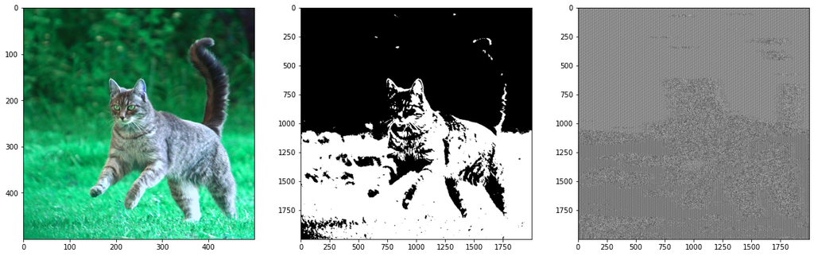

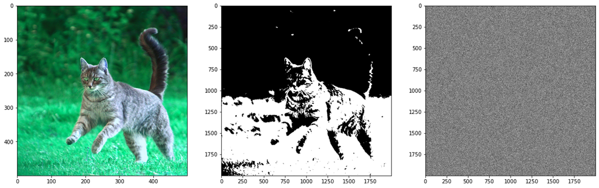

```python
import matplotlib.pyplot as plt
import cv2


def plot_pbm(image_paths: list):
  # Plot row
  fig, axs = plt.subplots(1, len(image_paths), figsize=(20, 20))
  for i, image_path in enumerate(image_paths):
    image = cv2.imread(image_path)
    axs[i].imshow(image, cmap='gray')
  plt.show()

plot_pbm(["assets/image.png", "assets/aes-256-ecb/org.pbm", "assets/aes-256-ecb/enc.pbm"])
plot_pbm(["assets/image.png", "assets/aes-256-cbc/org.pbm" ,"assets/aes-256-cbc/enc.pbm"])
```

จากการทดลองโดยใช้ AES-256-ECB (ดังในแถวที่ 1) และใช้ AES-256-CBC (ดังในแถวที่สอง) พบว่าการ encrypt โดยใช้ AES-256-ECB จะได้ผลลัพธ์ที่เห็นเค้าลางของภาพเดิมอยู่หน่อย ๆ ซึ่งอาจจะทำให้คนร้ายเดาได้ว่าภาพต้นฉบับเป็นภาพอะไร (ในกรณีที่ encrpyt password ก็อาจจะทำให้ผู้ร้ายเดารหัสต้นฉบับได้)

ในขณะเดียวกันแบบ AES-256-CBC จะมองไม่ค่อยเห็นอะไรเลย ซึ่งทำให้ผผู้ร้ายเดาออกได้ยากกว่า

ดังนั้นแนะนำให้ใช้ AES-256-CBC มากกว่า AES-256-ECB

(Encryption Protocol - Digital Signature)

1. Measure the performance of a hash function (sha1), RC4, Blowfish and DSA. Outline your experimental design. (Please use OpenSSL for your measurement)

```python
import os

# Generate large file with random data
def generate_large_file(file_path: str, size: int):
  with open(file_path, "wb") as f:
    f.write(os.urandom(size))

# Generate large file
generate_large_file("assets/large-file", 1024*1024*1024)
```

```python
# Generate DSA parameters and key
!mkdir -p assets/dsa
!openssl dsaparam 1024 < /dev/random > assets/dsa/dsaparam.pem
!openssl gendsa assets/dsa/dsaparam.pem -out assets/dsa/dsa_priv.pem
!openssl dsa -in assets/dsa/dsa_priv.pem -pubout -out assets/dsa/dsa_pub.pem
!openssl dgst -sha1 -out assets/dsa/dsa_digest.sha1 assets/large-file
```

```
Generating DSA parameters, 1024 bit long prime
This could take some time
.........+..................+...............+.........+.+........+......+.+............+.....+..+..........................+.............+++++++++++++++++++++++++++++++++++++++++++++++++++*
..........+....+..+..+...+++++++++++++++++++++++++++++++++++++++++++++++++++*
Generating DSA key, 1024 bits
read DSA key
writing DSA key
```

รัน command ดังนี้เพื่อวัดผลลัพธ์

```
for i in {1..10}
do
  time openssl dgst -sha1 -out /dev/null assets/large-file
done
```

```
for i in {1..10}
do
  time openssl enc -rc4 -nosalt -k -nopad -in assets/large-file -out /dev/null
done
```

```
for i in {1..10}
do
  time openssl enc -bf -nosalt -k -nopad -in assets/large-file -out /dev/null
done
```

```
for i in {1..10}
do
  time openssl dgst -dss1 -sign assets/dsa/dsa_priv.pem -out /dev/null assets/large-file
done
```

ได้ผลลัพธ์ดังนี้

| SHA1 | RC4 | Blowfish | DSA |
| --- | --- | --- | --- |
| 2.012 | 2.432 | 7.734 | 1.728 |
| 1.412 | 2.029 | 7.38 | 1.641 |
| 1.454 | 2.074 | 7.384 | 1.677 |
| 1.446 | 2.167 | 7.473 | 1.684 |
| 1.417 | 2.083 | 7.991 | 1.428 |
| 1.452 | 2.061 | 7.556 | 1.411 |
| 1.6 | 2.025 | 7.874 | 1.55 |
| 1.449 | 2.034 | 7.92 | 1.607 |
| 1.437 | 2.026 | 7.473 | 1.476 |
| 1.571 | 2.012 | 7.453 | 1.424 |

1. Comparing performance and security provided by each method.

## Answer

พบว่า

| Method | Time(s) |
| --- | --- |
| sha1 | 1.525 |
| rc4 | 2.0943 |
| blowfish | 7.6238 |
| dsa | 1.5626 |

ดังนั้น Method ที่ใช้เวลาช้าที่สุดคือ blowfish ซึ่งเป็น block cipher และมีความปลอดภัยสูง

ในขณะที่ sha1 จะเป็น method ที่เร็วที่สุด แต่มีความปลอดภัยต่ำ

1. Explain the mechanism underlying Digital Signature. How does it combine the strength and weakness of each encryption scheme?

## Answer

SHA1 จะเป็น method ที่มีความซับซ้อนน้อยจึงทำให้มีความเร็วสูง แต่มีความปลอดภัยต่ำ เพราะมีขนาดแค่ 160 bit เท่านั้น ซึ่งมีความเสี่ยงที่จะถูกเดาออกได้ นอกจากนี้ยังมีโอกาสที่จะ hash แล้วไปซ้ำกับข้อมูลอื่น ๆ ได้

RC4 จะเป็น method ในลักษณะ stream cipher ซึ่งมีความซับซ้อนมากขึ้น และใช้ XOR operation ในการ encrypt ข้อมูล แต่ stream cipher ก็มีวิธีโจมตีได้หลายหลาย ซึ่งก็มีความเสี่ยงที่จะถูกเดาออกได้

Blowfish จะเป็น method ในลักษณะ block cipher ซึ่งมีความซับซ้อนมากขึ้นมาก และมีโอกาสโจมตีได้ยากขึ้น แต่ใช้เวลาในการ encrypt ข้อมูลนานขึ้น

DSA เป็น Digital Signature Algorithm ซึ่่งก็คือการสร้าง key มาสองอันคือ public key และ private key จากนั้นเอาข้อมูลไป digest และ sign ด้วย key ที่สร้างขึ้น ซึ่งผลลัพธ์คือได้เวลาในการทำงานใกล้เคียงกับ SHA1 มาก